# Сеетевые технологии

## Настройка динамической маршрутизации в сетях IPv4 и IPv6

С PC1 пропингуйте PC2 и определим путь следования пакетов.

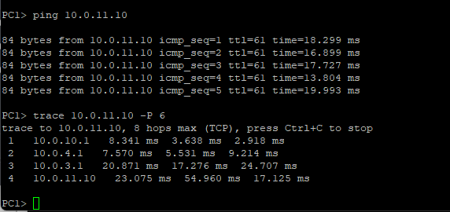

PC1 пинг PC2

## Настройка динамической маршрутизации в сетях IPv4 и IPv6

Просмотрим захваченный трафик.

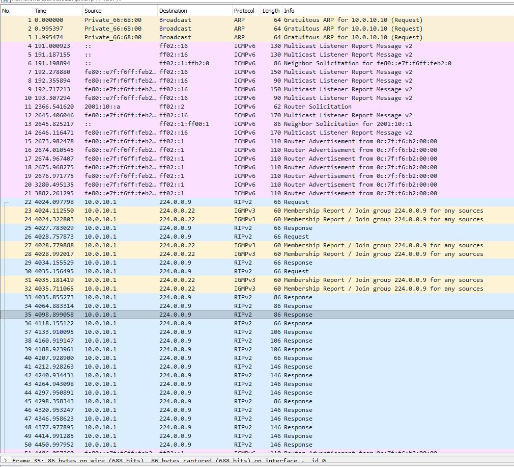

Анализ трафика

## Настройка динамической маршрутизации в сетях IPv4 и IPv6

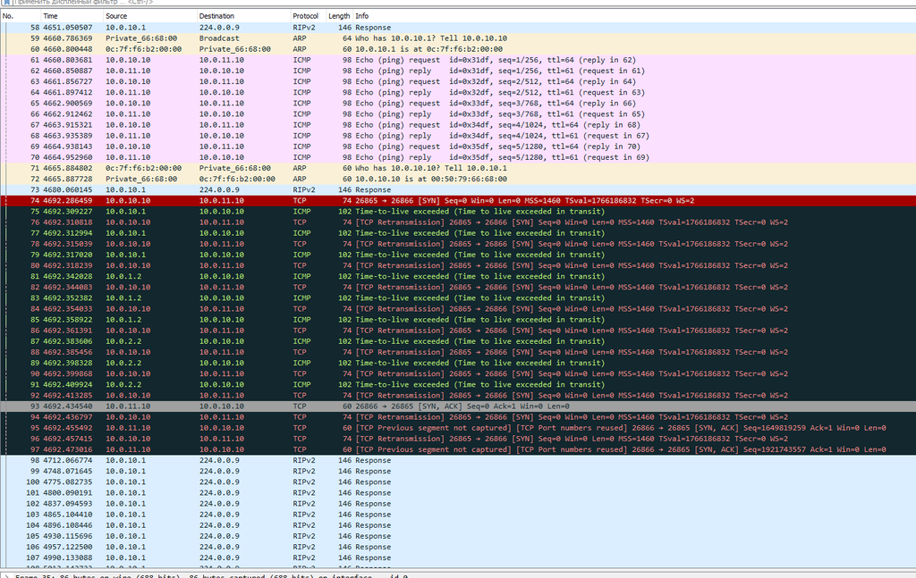

Анализ трафика

## Настройка динамической маршрутизации в сетях IPv4 и IPv6

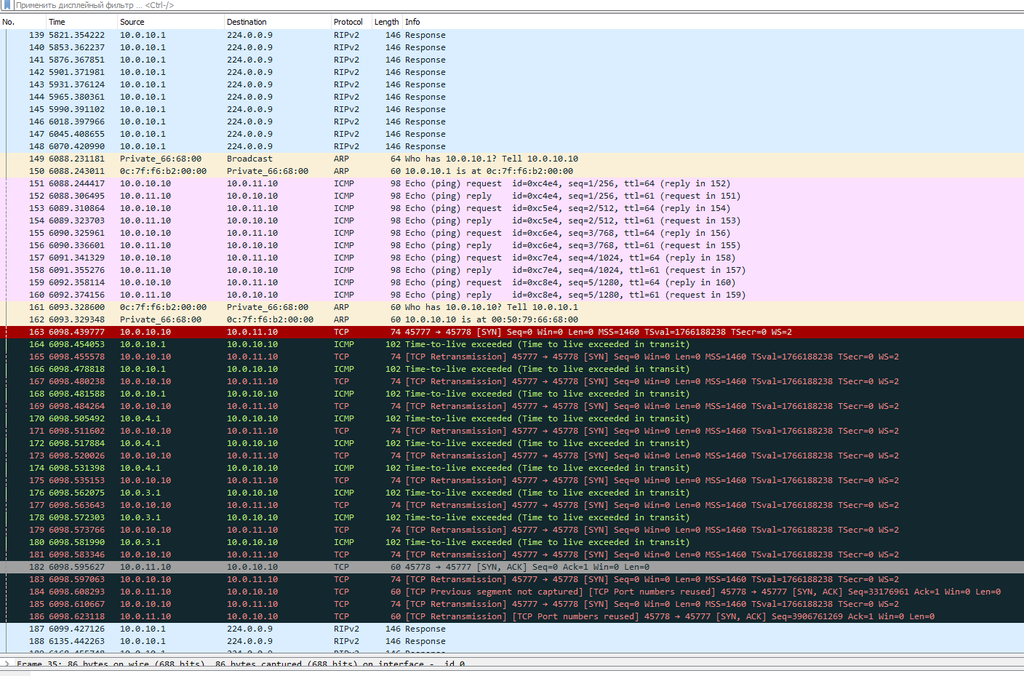

Анализ трафика

## Настройка динамической маршрутизации в сетях IPv4 и IPv6

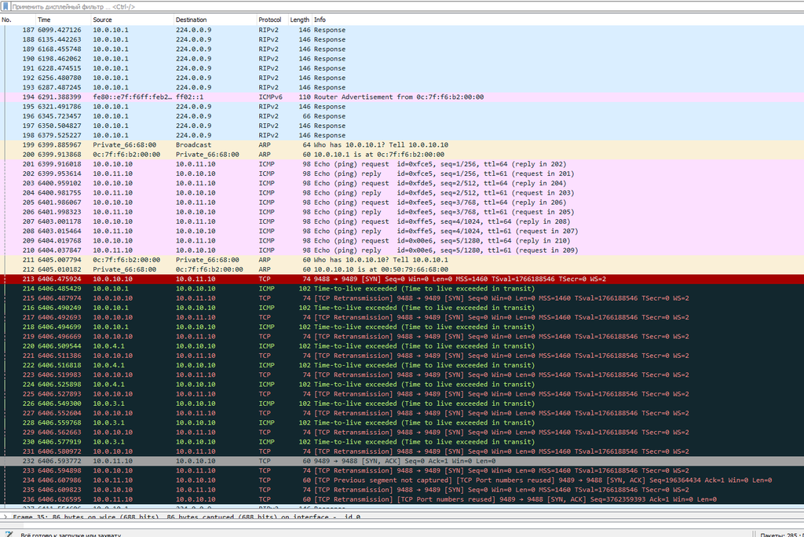

Анализ трафика

## Настройка динамической маршрутизации в сетях IPv4 и IPv6

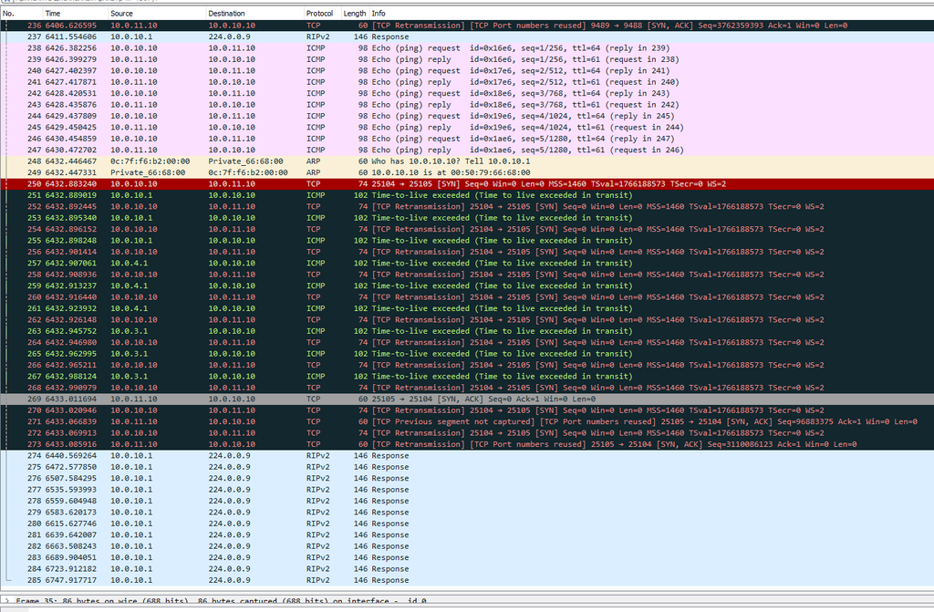

Анализ трафика

## Настройка динамической маршрутизации в сетях IPv4 и IPv6

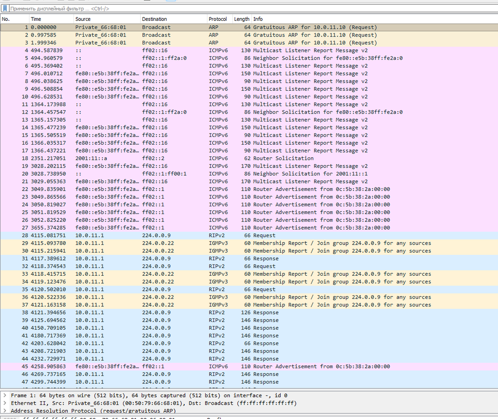

Анализ трафика

## Настройка динамической маршрутизации в сетях IPv4 и IPv6

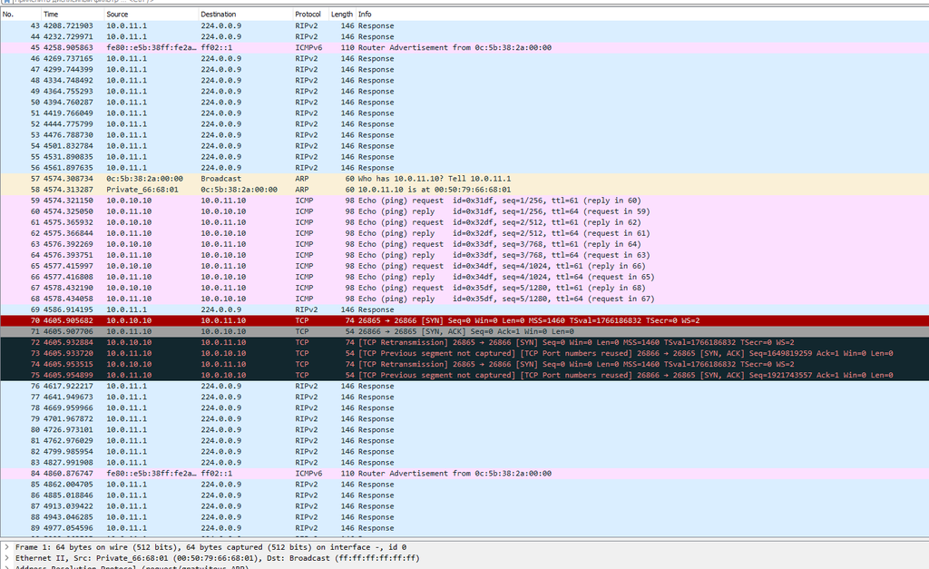

Анализ трафика

## Настройка динамической маршрутизации в сетях IPv4 и IPv6

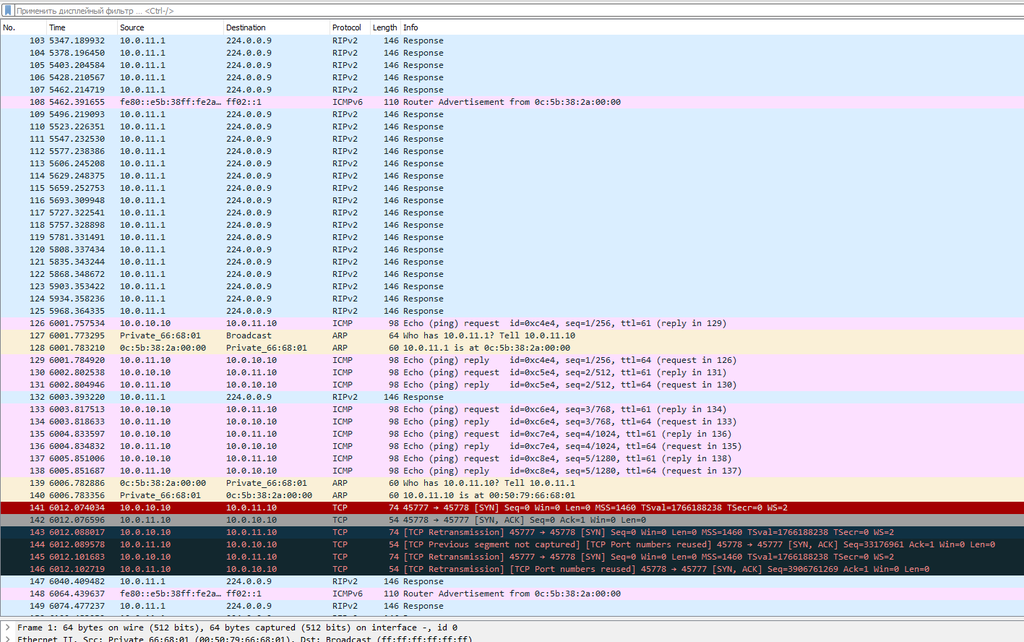

Анализ трафика

## Настройка динамической маршрутизации в сетях IPv4 и IPv6

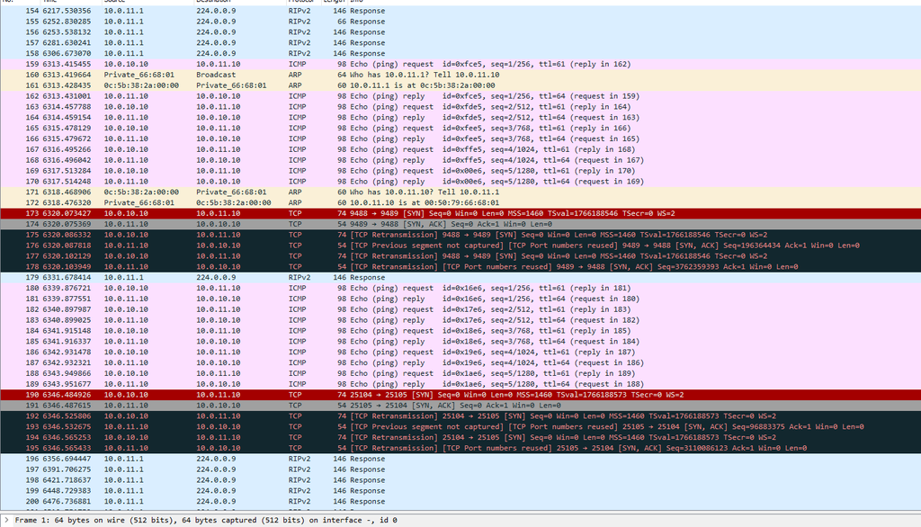

Анализ трафика

## Настройка динамической маршрутизации в сетях IPv4 и IPv6

На маршрутизаторах настроим RIPng для сетей IPv6.

msk-antoychubekova-gw-01.

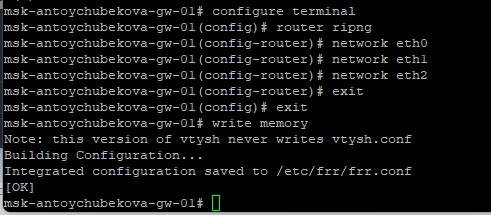

Настройка RIPng в msk-antoychubekova-gw-01

## Настройка динамической маршрутизации в сетях IPv4 и IPv6

msk-antoychubekova-gw-02.

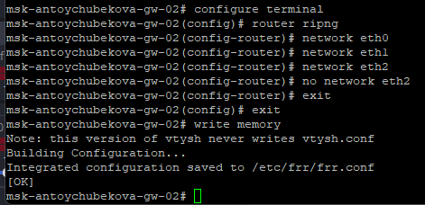

Настройка RIPng в msk-antoychubekova-gw-02

## Настройка динамической маршрутизации в сетях IPv4 и IPv6

msk-antoychubekova-gw-03.

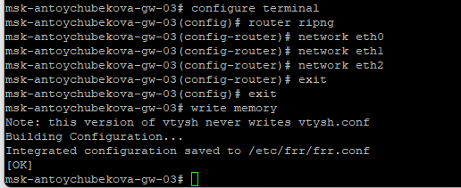

Настройка RIPng в msk-antoychubekova-gw-03

## Настройка динамической маршрутизации в сетях IPv4 и IPv6

msk-antoychubekova-gw-04.

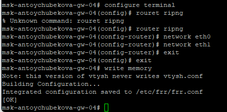

Настройка RIPng в msk-antoychubekova-gw-04

## Настройка динамической маршрутизации в сетях IPv4 и IPv6

Проверим пути прохождения пакетов. С PC1 пропингуем PC2 и определим путь следования пакетов.

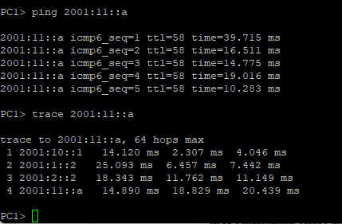

Пингование PC1 к PC2

## Настройка динамической маршрутизации в сетях IPv4 и IPv6

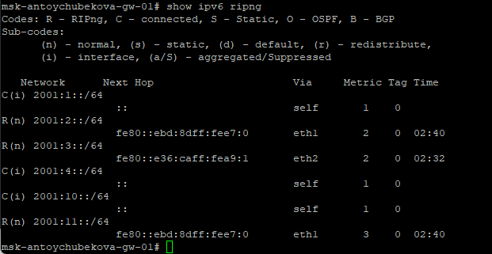

Метрики протокола RIPng

## Настройка динамической маршрутизации в сетях IPv4 и IPv6

Предположим, что пакет проходит через маршрутизатор msk-antoychubekova-gw-02. Отключим на маршрутизаторе msk-antoychubekova-gw-02 интерфейс.

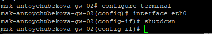

Отключение интерфейса

## Настройка динамической маршрутизации в сетях IPv4 и IPv6

Проверим метрики протокола RIPng. Мы видим, что по сравнению с предыдущим выводом изменились маршруты, полученные по RIPng и их параметры:

Изменились метрики маршрутов (стали 2 и 3), что говорит о том, что путь до них теперь рассчитывается иначе (возможно, изменился топология/доступность соседей).

Время (Time) обновилось — маршруты продолжают регулярно приниматься.

## Настройка динамической маршрутизации в сетях IPv4 и IPv6

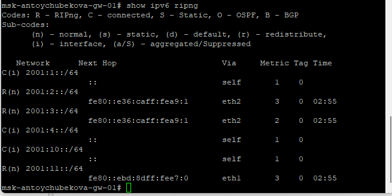

Метрики протокола RIPng

## Настройка динамической маршрутизации в сетях IPv4 и IPv6

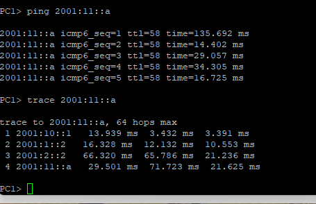

Пингование PC1 к PC2

## Настройка динамической маршрутизации в сетях IPv4 и IPv6

Просмотрим захваченный трафик.

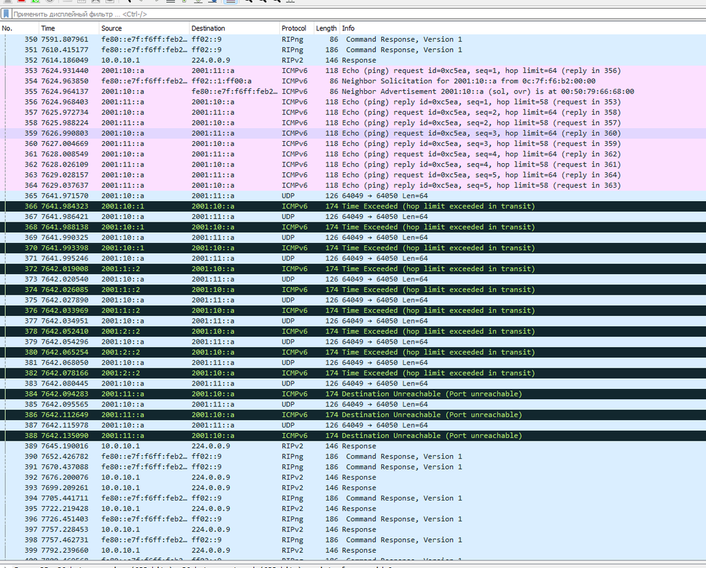

Анализ трафика

## Настройка динамической маршрутизации в сетях IPv4 и IPv6

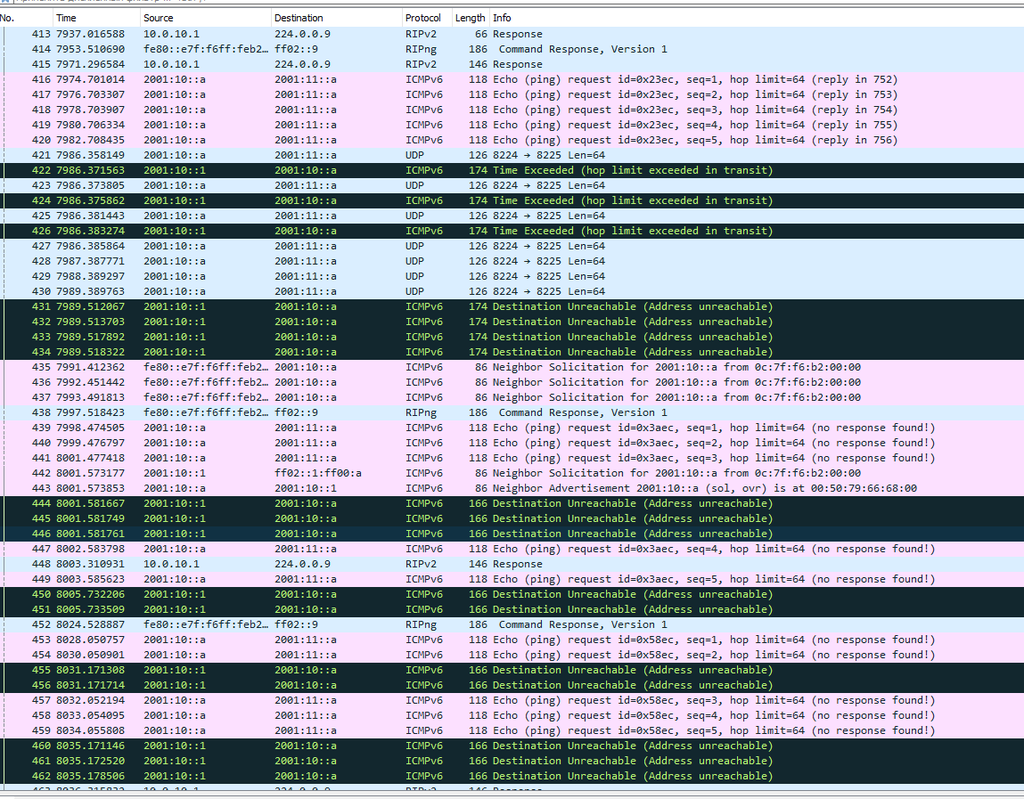

Анализ трафика

## Настройка динамической маршрутизации в сетях IPv4 и IPv6

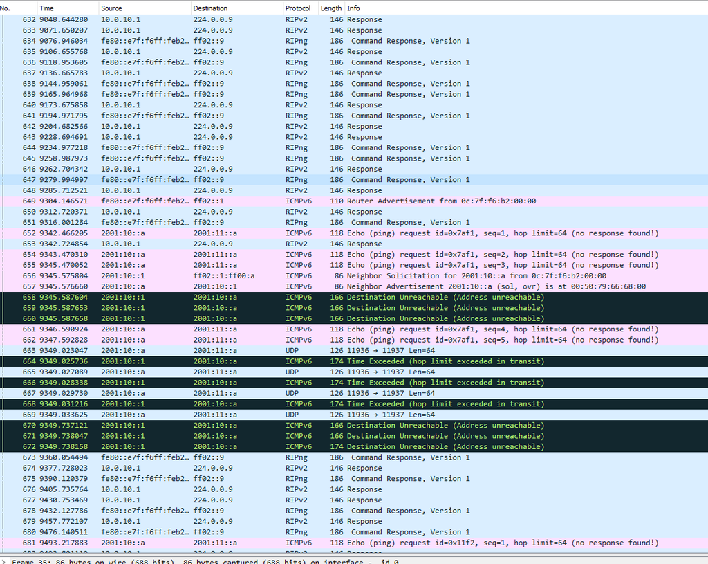

Анализ трафика

## Настройка динамической маршрутизации в сетях IPv4 и IPv6

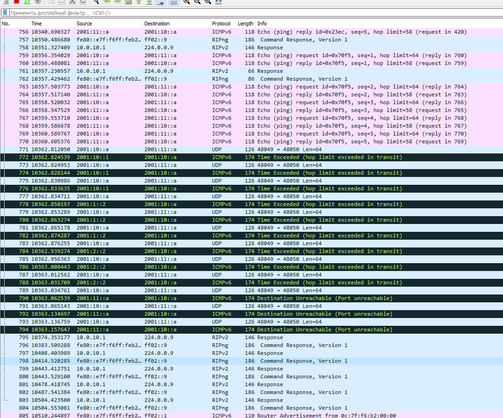

Анализ трафика

## Настройка динамической маршрутизации в сетях IPv4 и IPv6

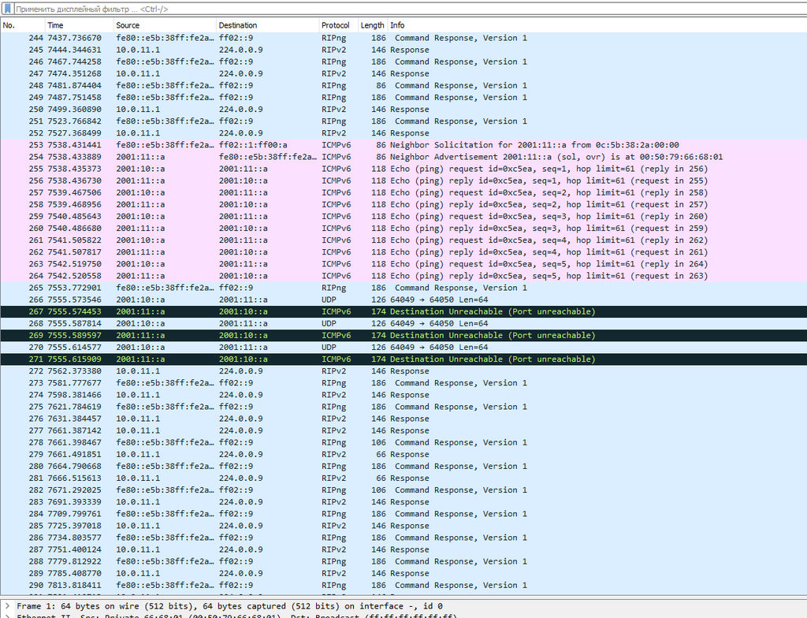

Анализ трафика

## Настройка динамической маршрутизации в сетях IPv4 и IPv6

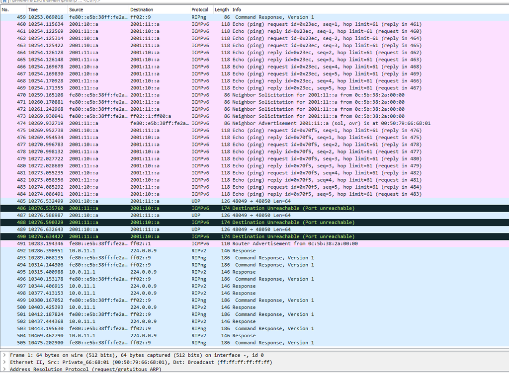

Анализ трафика

## Настройка динамической маршрутизации в сетях IPv4 и IPv6

OSPF — протокол динамической маршрутизации на основе состояния каналов. Поддерживает IPv4 (OSPFv2) и IPv6 (OSPFv3), работает на оборудовании разных производителей, поддерживает бесклассовую маршрутизацию, балансировку нагрузки и суммирование маршрутов. Метрика — стоимость, зависящая от скорости интерфейса, административное расстояние — 110.

Маршрутизаторы обмениваются Hello-пакетами (224.0.0.5 / FF02::5) для автоматического обнаружения соседей и формирования отношений соседства. OSPF использует три таблицы: соседей, топологии и маршрутизации. Передача обновлений ведётся по принципу SPF-алгоритма, который рассчитывает кратчайшие пути.

Сеть разделяется на области (area) для уменьшения таблиц и ускорения сходимости. Главная — область 0. Маршрутизаторы с несколькими областями — ABR, маршрутизаторы, соединяющие разные протоколы — ASBR. Для IPv6 используется OSPFv3, применяющий групповые адреса FF02::5 и FF02::6.

## Настройка динамической маршрутизации в сетях IPv4 и IPv6

На маршрутизаторах настроим OSPFv2 для сетей IPv4.

msk-antoychubekova-gw-01.

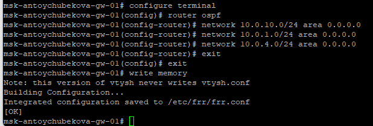

Настройка OSPFv2 в msk-antoychubekova-gw-01 для IPv4

## Настройка динамической маршрутизации в сетях IPv4 и IPv6

msk-antoychubekova-gw-02.

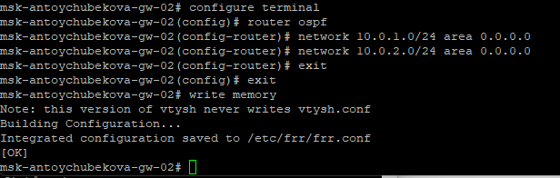

Настройка OSPFv2 в msk-antoychubekova-gw-02 для IPv4

## Настройка динамической маршрутизации в сетях IPv4 и IPv6

msk-antoychubekova-gw-03.

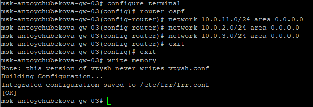

Настройка OSPFv2 в msk-antoychubekova-gw-03 для IPv4

## Настройка динамической маршрутизации в сетях IPv4 и IPv6

msk-antoychubekova-gw-04.

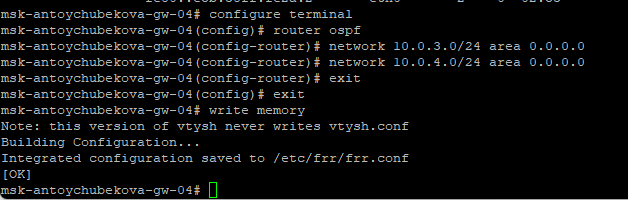

Настройка OSPFv2 в msk-antoychubekova-gw-04 для IPv4

## Настройка динамической маршрутизации в сетях IPv4 и IPv6

C PC1 пропингуем PC2 и определим путь следования пакетов.

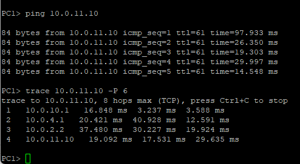

Пингование PC1 к PC2

## Настройка динамической маршрутизации в сетях IPv4 и IPv6

Проверим таблицу маршрутизации протокола OSPFv2.

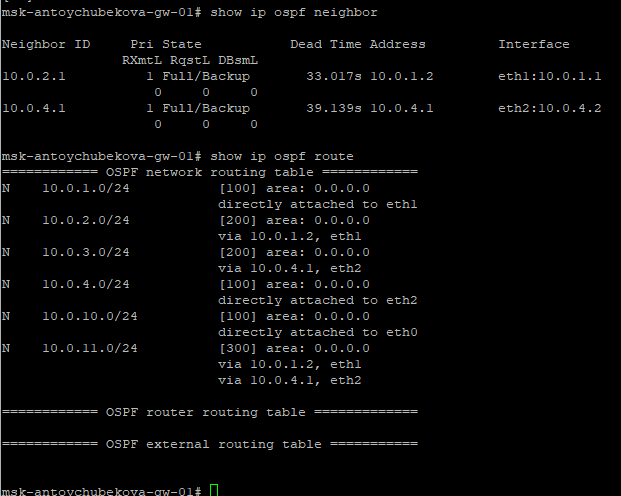

Таблица маршрутизации протокола OSPFv2

## Настройка динамической маршрутизации в сетях IPv4 и IPv6

Предположим, что пакет проходит через маршрутизатор msk-antoychubekova-gw-02. Отключим на маршрутизаторе msk-antoychubekova-gw-02 интерфейс.

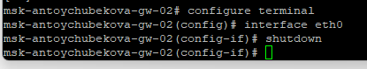

Отключение интерфейса

## Настройка динамической маршрутизации в сетях IPv4 и IPv6

Проверим таблицу маршрутизации протокола OSPFv2.

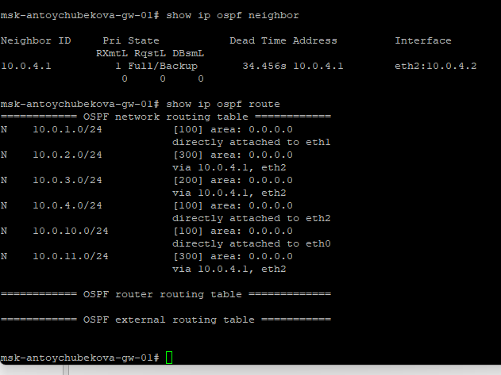

Таблица маршрутизации протокола OSPFv2

## Настройка динамической маршрутизации в сетях IPv4 и IPv6

С PC1 пропингуйте PC2 и определим путь следования пакетов. Примерное время, за которое восстановится маршрут равняется 1 минуте.

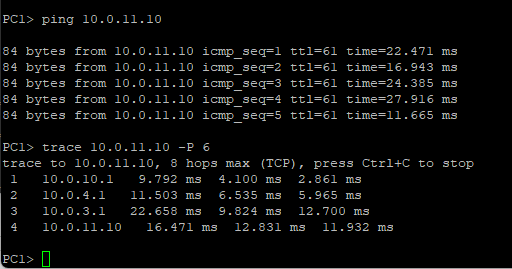

Пингование PC1 к PC2

## Настройка динамической маршрутизации в сетях IPv4 и IPv6

Включим на маршрутизаторе msk-antoychubekova-gw-02 интерфейс.

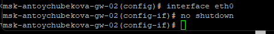

Включение интерфейса

## Настройка динамической маршрутизации в сетях IPv4 и IPv6

С PC1 пропингуйте PC2 и определим путь следования пакетов.

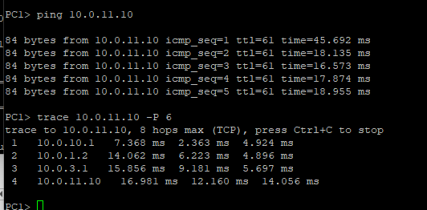

Пингование PC1 к PC2

## Настройка динамической маршрутизации в сетях IPv4 и IPv6

Просмотрим захваченный трафик.

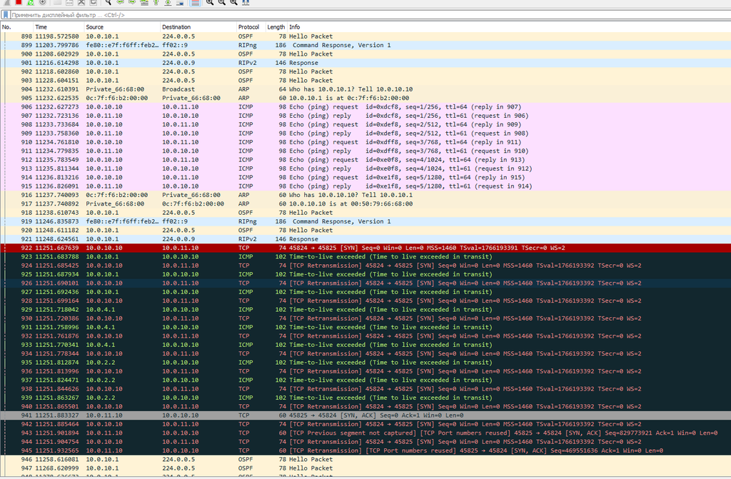

Анализ трафика

## Настройка динамической маршрутизации в сетях IPv4 и IPv6

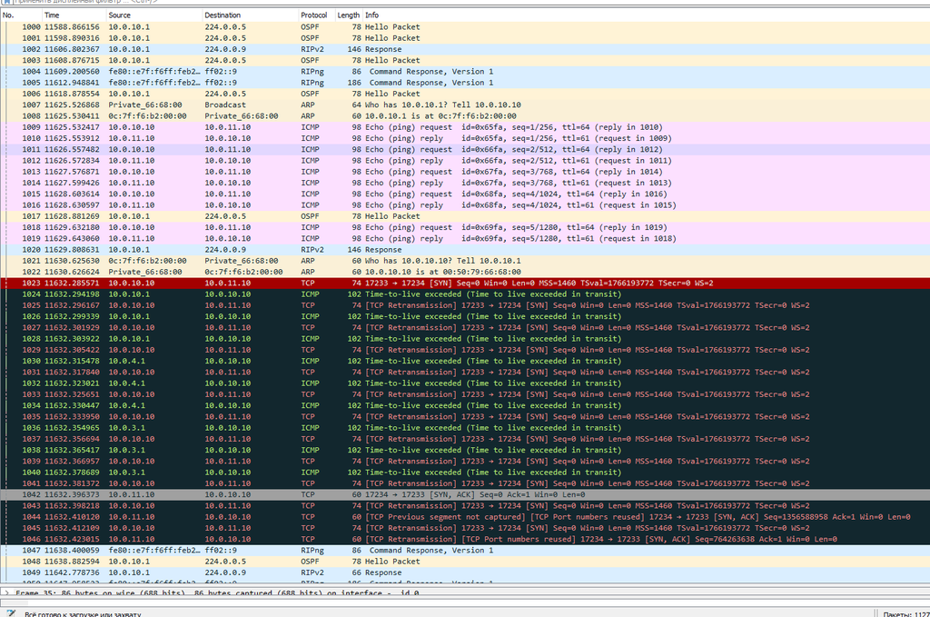

Анализ трафика

## Настройка динамической маршрутизации в сетях IPv4 и IPv6

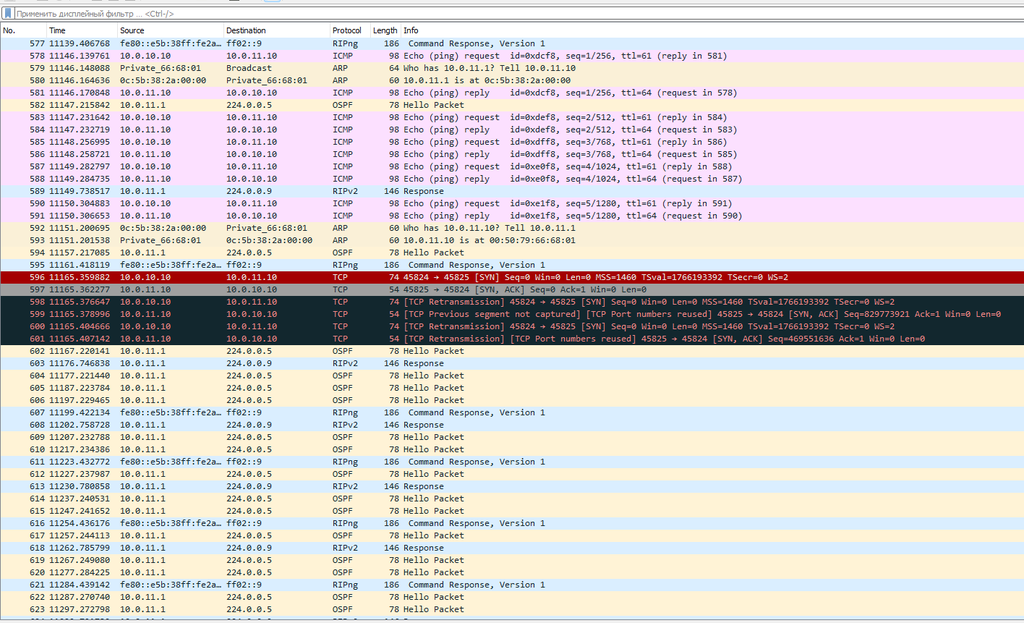

Анализ трафика

## Настройка динамической маршрутизации в сетях IPv4 и IPv6

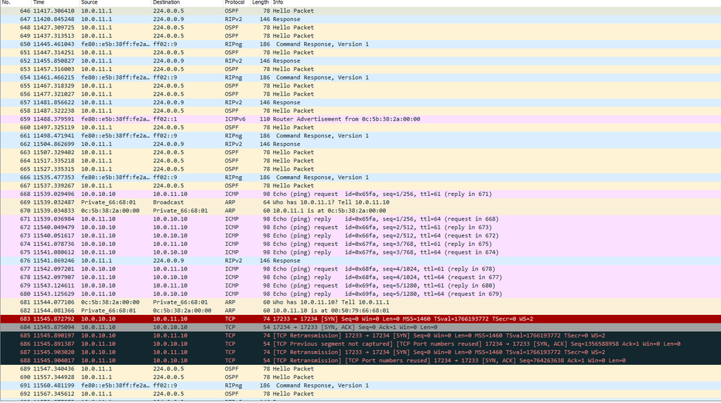

Анализ трафика

## Настройка динамической маршрутизации в сетях IPv4 и IPv6

На маршрутизаторах настроим OSPFv3 для сетей IPv6.

msk-antoychubekova-gw-01.

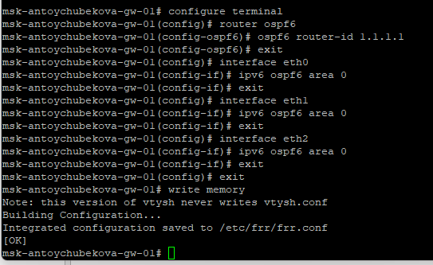

Настройка OSPFv3 в msk-antoychubekova-gw-01 для IPv6

## Настройка динамической маршрутизации в сетях IPv4 и IPv6

msk-antoychubekova-gw-02.

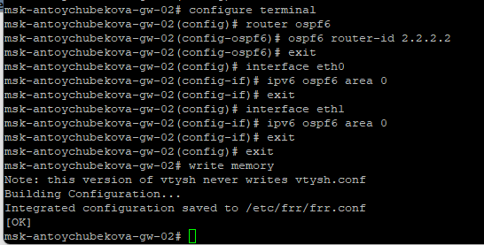

Настройка OSPFv3 в msk-antoychubekova-gw-02 для IPv6

## Настройка динамической маршрутизации в сетях IPv4 и IPv6

msk-antoychubekova-gw-03.

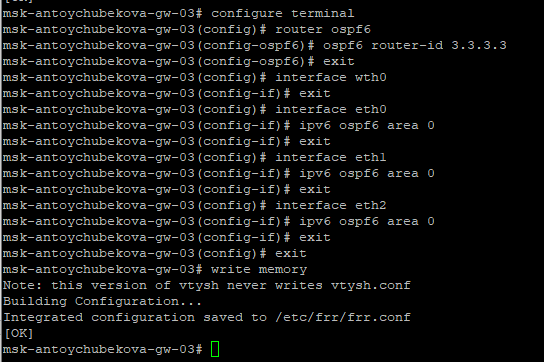

Настройка OSPFv3 в msk-antoychubekova-gw-03 для IPv6

## Настройка динамической маршрутизации в сетях IPv4 и IPv6

msk-antoychubekova-gw-04.

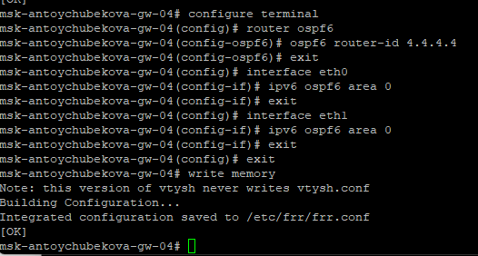

Настройка OSPFv3 в msk-antoychubekova-gw-04 для IPv6

## Настройка динамической маршрутизации в сетях IPv4 и IPv6

С PC1 пропингуем PC2 и определим путь следования пакетов.

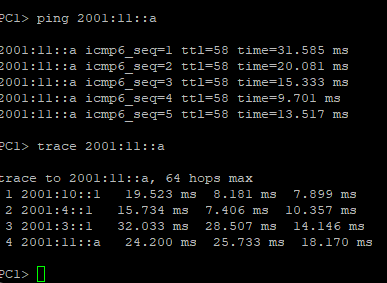

Пингование PC1 к PC2

## Настройка динамической маршрутизации в сетях IPv4 и IPv6

Проверим таблицу маршрутизации протокола OSPFv3.

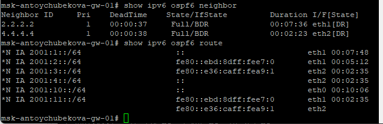

Таблица маршрутизации протокола OSPFv3

## Настройка динамической маршрутизации в сетях IPv4 и IPv6

Предположим, что пакет проходит через маршрутизатор msk-antoychubekova-gw-02. Отключим на маршрутизаторе msk-antoychubekova-gw-02 интерфейс.

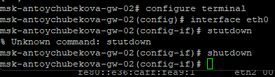

Отключение интерфейса

## Настройка динамической маршрутизации в сетях IPv4 и IPv6

Проверим таблицу маршрутизации протокола OSPFv3.

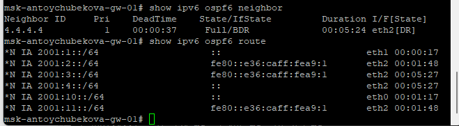

Таблица маршрутизации протокола OSPFv3

## Настройка динамической маршрутизации в сетях IPv4 и IPv6

С PC1 пропингуем PC2 и определим путь следования пакетов. Примерное время, за которое восстановится маршрут равно минуте.

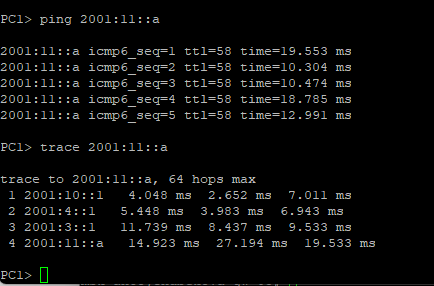

Пингование PC1 к PC2

## Настройка динамической маршрутизации в сетях IPv4 и IPv6

Включим на маршрутизаторе msk-antoychubekova-gw-02 интерфейс.

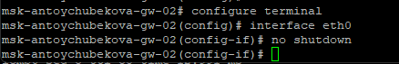

Включение интерфейса

## Настройка динамической маршрутизации в сетях IPv4 и IPv6

С PC1 пропингуем PC2 и определим путь следования пакетов.

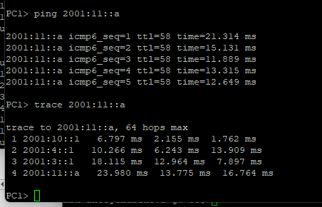

Пингование PC1 к PC2

## Настройка динамической маршрутизации в сетях IPv4 и IPv6

Просмотрим захваченный трафик.

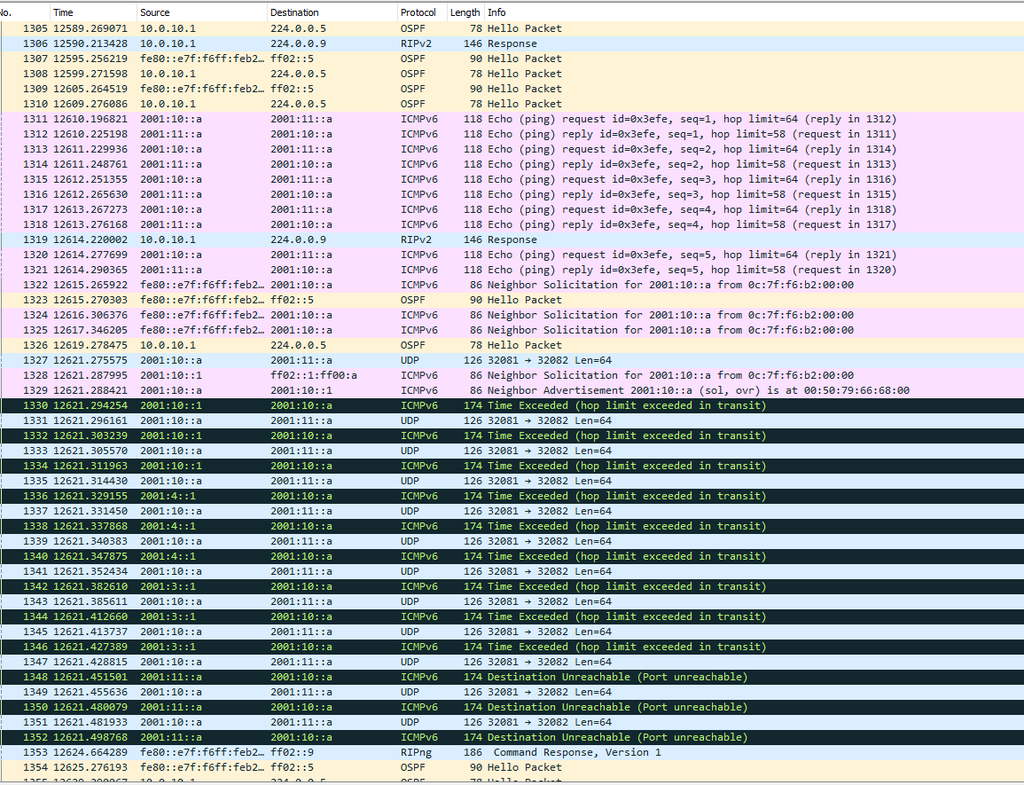

Анализ трафика

## Настройка динамической маршрутизации в сетях IPv4 и IPv6

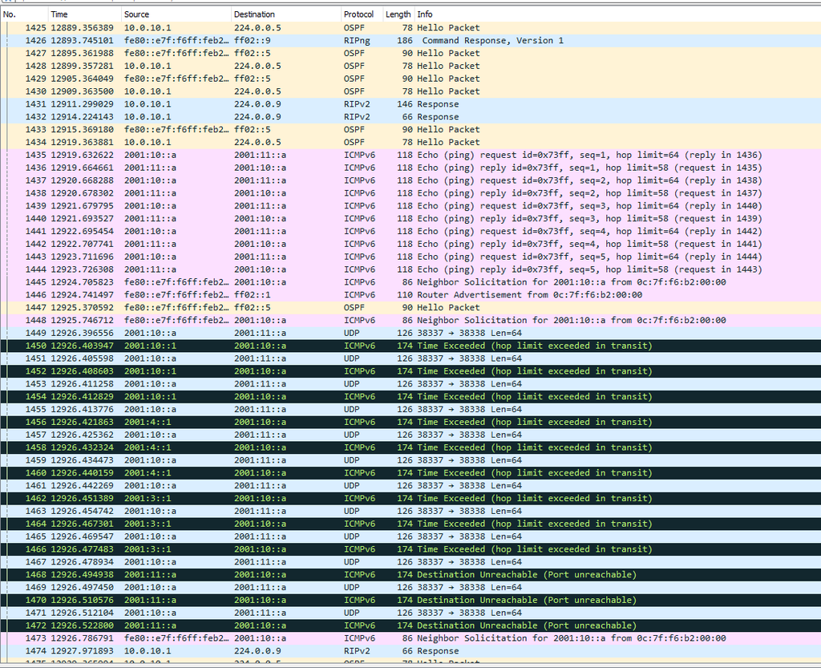

Анализ трафика

## Настройка динамической маршрутизации в сетях IPv4 и IPv6

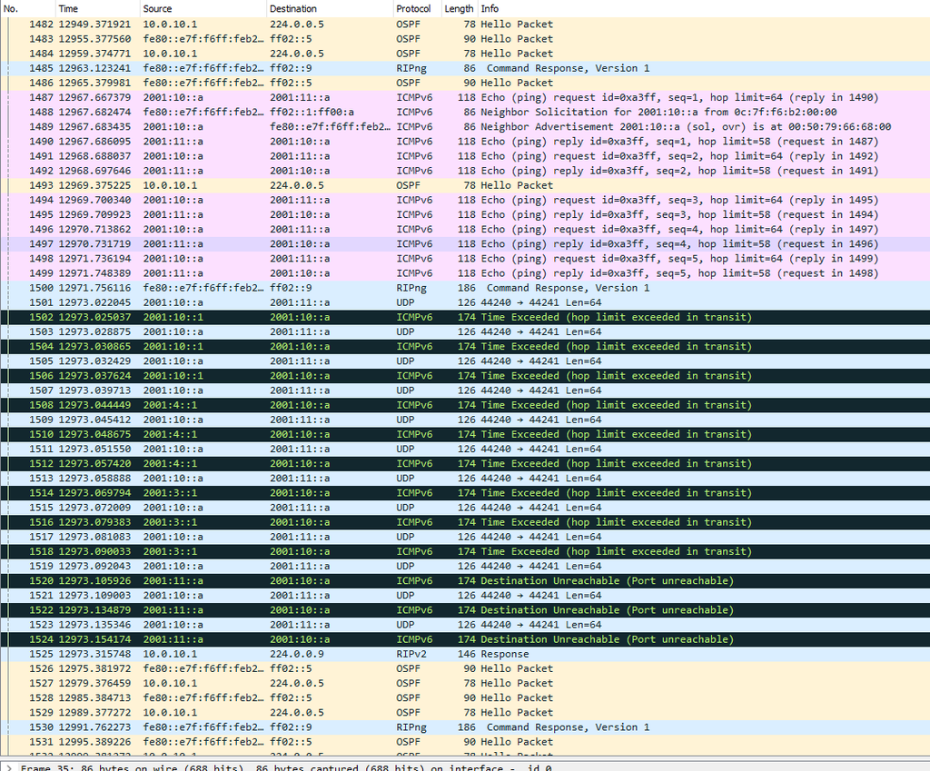

Анализ трафика

## Настройка динамической маршрутизации в сетях IPv4 и IPv6

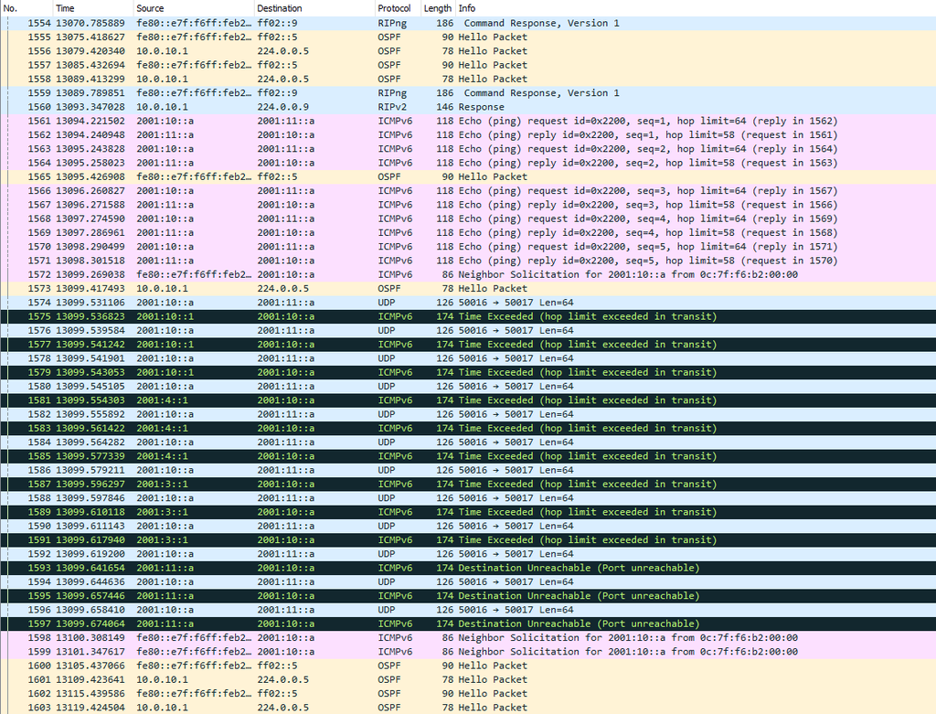

Анализ трафика

## Построение туннеля IPv6–IPv4

Создадим новый проект в GNS3. В рабочем пространстве разместим и соединим устройства в соответствии с топологией, приведенной в лабораторной работе. Используем маршрутизаторы VyOS. Изменим отображаемые названия устройств. На соединении между первым и третьим маршрутизаторами подключим анализатор трафика.

[figure not shown]

Топология сети

## Построение туннеля IPv6–IPv4

Присвойте адреса оконечным устройствам PC1 и PC2

[figure not shown]

Присвоение адресов

## Построение туннеля IPv6–IPv4

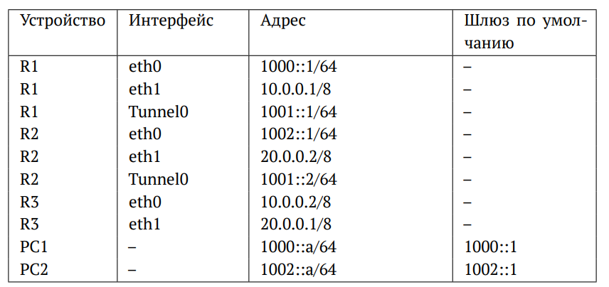

Таблица адресации

## Построение туннеля IPv6–IPv4

Установим систему на маршрутизаторы VyOS. На маршрутизаторах перейдем в режим конфигурирования, изменим имя каждого устройства.

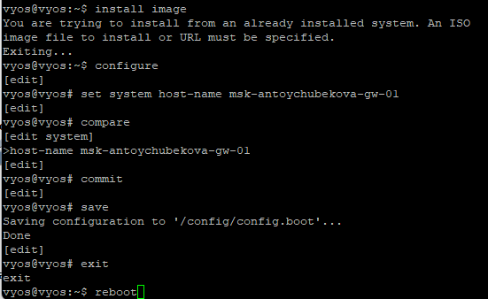

Изменение имени устройства